# Optimal Treatment Analysis

## Outcome Variable

**Outcome Variable:** ever_stunted

## Predictor Variables

**Intervention Variable:** exclfeed6

**Adjustment Set:**

- arm
- sex
- W_mage
- meducyrs
- feducyrs
- hhwealth_quart
- hfoodsec
- W_mhtcm
- vagbrth
- W_gagebrth
- W_birthwt
- W_birthlen
- W_nrooms
- W_nchldlt5
- month
- brthmon
- W_parity
- impfloor
- impsan
- safeh20
- delta_W_mage
- delta_meducyrs
- delta_feducyrs
- delta_hhwealth_quart
- delta_hfoodsec
- delta_W_mhtcm
- delta_vagbrth
- delta_W_gagebrth
- delta_W_birthwt
- delta_W_birthlen
- delta_W_nrooms
- delta_W_nchldlt5
- delta_month
- delta_brthmon
- delta_W_parity
- delta_impfloor
- delta_impsan
- delta_safeh20

## Stratifying Variables

The analysis was stratified on these variable(s):

- agecat
- studyid
- country

## Data Summary

| agecat | studyid | country | exclfeed6 | ever_stunted | n_cell | n |
| --- | --- | --- | --- | --- | --- | --- |
| 0-24 months (no birth st.) | ki0047075b-MAL-ED | BANGLADESH | 1 | 0 | 20 | 198 |
| 0-24 months (no birth st.) | ki0047075b-MAL-ED | BANGLADESH | 1 | 1 | 28 | 198 |
| 0-24 months (no birth st.) | ki0047075b-MAL-ED | BANGLADESH | 0 | 0 | 71 | 198 |
| 0-24 months (no birth st.) | ki0047075b-MAL-ED | BANGLADESH | 0 | 1 | 79 | 198 |
| 0-24 months (no birth st.) | ki0047075b-MAL-ED | BRAZIL | 1 | 0 | 13 | 191 |
| 0-24 months (no birth st.) | ki0047075b-MAL-ED | BRAZIL | 1 | 1 | 1 | 191 |
| 0-24 months (no birth st.) | ki0047075b-MAL-ED | BRAZIL | 0 | 0 | 150 | 191 |
| 0-24 months (no birth st.) | ki0047075b-MAL-ED | BRAZIL | 0 | 1 | 27 | 191 |
| 0-24 months (no birth st.) | ki0047075b-MAL-ED | INDIA | 1 | 0 | 2 | 194 |
| 0-24 months (no birth st.) | ki0047075b-MAL-ED | INDIA | 1 | 1 | 1 | 194 |
| 0-24 months (no birth st.) | ki0047075b-MAL-ED | INDIA | 0 | 0 | 86 | 194 |
| 0-24 months (no birth st.) | ki0047075b-MAL-ED | INDIA | 0 | 1 | 105 | 194 |
| 0-24 months (no birth st.) | ki0047075b-MAL-ED | NEPAL | 1 | 0 | 11 | 208 |
| 0-24 months (no birth st.) | ki0047075b-MAL-ED | NEPAL | 1 | 1 | 4 | 208 |
| 0-24 months (no birth st.) | ki0047075b-MAL-ED | NEPAL | 0 | 0 | 143 | 208 |
| 0-24 months (no birth st.) | ki0047075b-MAL-ED | NEPAL | 0 | 1 | 50 | 208 |
| 0-24 months (no birth st.) | ki0047075b-MAL-ED | PERU | 1 | 0 | 2 | 238 |
| 0-24 months (no birth st.) | ki0047075b-MAL-ED | PERU | 1 | 1 | 7 | 238 |
| 0-24 months (no birth st.) | ki0047075b-MAL-ED | PERU | 0 | 0 | 90 | 238 |
| 0-24 months (no birth st.) | ki0047075b-MAL-ED | PERU | 0 | 1 | 139 | 238 |
| 0-24 months (no birth st.) | ki0047075b-MAL-ED | SOUTH AFRICA | 1 | 0 | 0 | 222 |
| 0-24 months (no birth st.) | ki0047075b-MAL-ED | SOUTH AFRICA | 1 | 1 | 0 | 222 |
| 0-24 months (no birth st.) | ki0047075b-MAL-ED | SOUTH AFRICA | 0 | 0 | 96 | 222 |
| 0-24 months (no birth st.) | ki0047075b-MAL-ED | SOUTH AFRICA | 0 | 1 | 126 | 222 |
| 0-24 months (no birth st.) | ki0047075b-MAL-ED | TANZANIA, UNITED REPUBLIC OF | 1 | 0 | 0 | 210 |
| 0-24 months (no birth st.) | ki0047075b-MAL-ED | TANZANIA, UNITED REPUBLIC OF | 1 | 1 | 1 | 210 |
| 0-24 months (no birth st.) | ki0047075b-MAL-ED | TANZANIA, UNITED REPUBLIC OF | 0 | 0 | 35 | 210 |
| 0-24 months (no birth st.) | ki0047075b-MAL-ED | TANZANIA, UNITED REPUBLIC OF | 0 | 1 | 174 | 210 |
| 0-24 months (no birth st.) | ki1000108-CMC-V-BCS-2002 | INDIA | 1 | 0 | 1 | 14 |
| 0-24 months (no birth st.) | ki1000108-CMC-V-BCS-2002 | INDIA | 1 | 1 | 13 | 14 |

[output cut: 186 more lines]

The following strata were considered:

- agecat: 0-24 months (no birth st.), studyid: ki0047075b-MAL-ED, country: BANGLADESH
- agecat: 0-24 months (no birth st.), studyid: ki0047075b-MAL-ED, country: BRAZIL
- agecat: 0-24 months (no birth st.), studyid: ki0047075b-MAL-ED, country: INDIA
- agecat: 0-24 months (no birth st.), studyid: ki0047075b-MAL-ED, country: NEPAL
- agecat: 0-24 months (no birth st.), studyid: ki0047075b-MAL-ED, country: PERU
- agecat: 0-24 months (no birth st.), studyid: ki0047075b-MAL-ED, country: SOUTH AFRICA
- agecat: 0-24 months (no birth st.), studyid: ki0047075b-MAL-ED, country: TANZANIA, UNITED REPUBLIC OF
- agecat: 0-24 months (no birth st.), studyid: ki1000108-CMC-V-BCS-2002, country: INDIA
- agecat: 0-24 months (no birth st.), studyid: ki1000108-IRC, country: INDIA
- agecat: 0-24 months (no birth st.), studyid: ki1000109-EE, country: PAKISTAN
- agecat: 0-24 months (no birth st.), studyid: ki1000304b-SAS-CompFeed, country: INDIA
- agecat: 0-24 months (no birth st.), studyid: ki1000304b-SAS-FoodSuppl, country: INDIA
- agecat: 0-24 months (no birth st.), studyid: ki1017093b-PROVIDE, country: BANGLADESH
- agecat: 0-24 months (no birth st.), studyid: ki1101329-Keneba, country: GAMBIA
- agecat: 0-24 months (no birth st.), studyid: ki1113344-GMS-Nepal, country: NEPAL
- agecat: 0-24 months (no birth st.), studyid: ki1148112-LCNI-5, country: MALAWI
- agecat: 0-24 months (no birth st.), studyid: kiGH5241-JiVitA-3, country: BANGLADESH
- agecat: 0-24 months (no birth st.), studyid: kiGH5241-JiVitA-4, country: BANGLADESH
- agecat: 0-6 months (no birth st.), studyid: ki0047075b-MAL-ED, country: BANGLADESH
- agecat: 0-6 months (no birth st.), studyid: ki0047075b-MAL-ED, country: BRAZIL
- agecat: 0-6 months (no birth st.), studyid: ki0047075b-MAL-ED, country: INDIA
- agecat: 0-6 months (no birth st.), studyid: ki0047075b-MAL-ED, country: NEPAL
- agecat: 0-6 months (no birth st.), studyid: ki0047075b-MAL-ED, country: PERU
- agecat: 0-6 months (no birth st.), studyid: ki0047075b-MAL-ED, country: SOUTH AFRICA
- agecat: 0-6 months (no birth st.), studyid: ki0047075b-MAL-ED, country: TANZANIA, UNITED REPUBLIC OF
- agecat: 0-6 months (no birth st.), studyid: ki1000108-CMC-V-BCS-2002, country: INDIA
- agecat: 0-6 months (no birth st.), studyid: ki1000108-IRC, country: INDIA
- agecat: 0-6 months (no birth st.), studyid: ki1000109-EE, country: PAKISTAN
- agecat: 0-6 months (no birth st.), studyid: ki1000304b-SAS-CompFeed, country: INDIA
- agecat: 0-6 months (no birth st.), studyid: ki1000304b-SAS-FoodSuppl, country: INDIA
- agecat: 0-6 months (no birth st.), studyid: ki1017093b-PROVIDE, country: BANGLADESH
- agecat: 0-6 months (no birth st.), studyid: ki1101329-Keneba, country: GAMBIA
- agecat: 0-6 months (no birth st.), studyid: ki1113344-GMS-Nepal, country: NEPAL
- agecat: 0-6 months (no birth st.), studyid: ki1148112-LCNI-5, country: MALAWI
- agecat: 0-6 months (no birth st.), studyid: kiGH5241-JiVitA-3, country: BANGLADESH
- agecat: 0-6 months (no birth st.), studyid: kiGH5241-JiVitA-4, country: BANGLADESH
- agecat: 6-24 months, studyid: ki0047075b-MAL-ED, country: BANGLADESH
- agecat: 6-24 months, studyid: ki0047075b-MAL-ED, country: BRAZIL
- agecat: 6-24 months, studyid: ki0047075b-MAL-ED, country: INDIA
- agecat: 6-24 months, studyid: ki0047075b-MAL-ED, country: NEPAL
- agecat: 6-24 months, studyid: ki0047075b-MAL-ED, country: PERU
- agecat: 6-24 months, studyid: ki0047075b-MAL-ED, country: SOUTH AFRICA
- agecat: 6-24 months, studyid: ki0047075b-MAL-ED, country: TANZANIA, UNITED REPUBLIC OF
- agecat: 6-24 months, studyid: ki1000108-CMC-V-BCS-2002, country: INDIA
- agecat: 6-24 months, studyid: ki1000108-IRC, country: INDIA
- agecat: 6-24 months, studyid: ki1000109-EE, country: PAKISTAN
- agecat: 6-24 months, studyid: ki1000304b-SAS-CompFeed, country: INDIA
- agecat: 6-24 months, studyid: ki1000304b-SAS-FoodSuppl, country: INDIA
- agecat: 6-24 months, studyid: ki1017093b-PROVIDE, country: BANGLADESH
- agecat: 6-24 months, studyid: ki1101329-Keneba, country: GAMBIA
- agecat: 6-24 months, studyid: ki1113344-GMS-Nepal, country: NEPAL
- agecat: 6-24 months, studyid: ki1148112-LCNI-5, country: MALAWI
- agecat: 6-24 months, studyid: kiGH5241-JiVitA-3, country: BANGLADESH
- agecat: 6-24 months, studyid: kiGH5241-JiVitA-4, country: BANGLADESH

### Dropped Strata

Some strata were dropped due to rare outcomes:

- agecat: 0-24 months (no birth st.), studyid: ki0047075b-MAL-ED, country: BRAZIL
- agecat: 0-24 months (no birth st.), studyid: ki0047075b-MAL-ED, country: INDIA
- agecat: 0-24 months (no birth st.), studyid: ki0047075b-MAL-ED, country: NEPAL
- agecat: 0-24 months (no birth st.), studyid: ki0047075b-MAL-ED, country: PERU
- agecat: 0-24 months (no birth st.), studyid: ki0047075b-MAL-ED, country: SOUTH AFRICA
- agecat: 0-24 months (no birth st.), studyid: ki0047075b-MAL-ED, country: TANZANIA, UNITED REPUBLIC OF
- agecat: 0-24 months (no birth st.), studyid: ki1000108-CMC-V-BCS-2002, country: INDIA
- agecat: 0-24 months (no birth st.), studyid: ki1000108-IRC, country: INDIA
- agecat: 0-24 months (no birth st.), studyid: ki1000304b-SAS-FoodSuppl, country: INDIA
- agecat: 0-6 months (no birth st.), studyid: ki0047075b-MAL-ED, country: BRAZIL
- agecat: 0-6 months (no birth st.), studyid: ki0047075b-MAL-ED, country: INDIA
- agecat: 0-6 months (no birth st.), studyid: ki0047075b-MAL-ED, country: NEPAL
- agecat: 0-6 months (no birth st.), studyid: ki0047075b-MAL-ED, country: PERU
- agecat: 0-6 months (no birth st.), studyid: ki0047075b-MAL-ED, country: SOUTH AFRICA
- agecat: 0-6 months (no birth st.), studyid: ki0047075b-MAL-ED, country: TANZANIA, UNITED REPUBLIC OF
- agecat: 0-6 months (no birth st.), studyid: ki1000108-CMC-V-BCS-2002, country: INDIA
- agecat: 0-6 months (no birth st.), studyid: ki1000108-IRC, country: INDIA
- agecat: 0-6 months (no birth st.), studyid: ki1000304b-SAS-FoodSuppl, country: INDIA
- agecat: 0-6 months (no birth st.), studyid: ki1148112-LCNI-5, country: MALAWI
- agecat: 6-24 months, studyid: ki0047075b-MAL-ED, country: BRAZIL
- agecat: 6-24 months, studyid: ki0047075b-MAL-ED, country: INDIA
- agecat: 6-24 months, studyid: ki0047075b-MAL-ED, country: NEPAL
- agecat: 6-24 months, studyid: ki0047075b-MAL-ED, country: PERU
- agecat: 6-24 months, studyid: ki0047075b-MAL-ED, country: SOUTH AFRICA
- agecat: 6-24 months, studyid: ki0047075b-MAL-ED, country: TANZANIA, UNITED REPUBLIC OF
- agecat: 6-24 months, studyid: ki1000108-CMC-V-BCS-2002, country: INDIA
- agecat: 6-24 months, studyid: ki1000108-IRC, country: INDIA
- agecat: 6-24 months, studyid: ki1000304b-SAS-CompFeed, country: INDIA
- agecat: 6-24 months, studyid: ki1000304b-SAS-FoodSuppl, country: INDIA

## Methods Detail

We’re interested in the causal parameters $E[Y_a]$ for all values of $a \in \mathcal{A}$. These parameters represent the mean outcome if, possibly contrary to fact, we intervened to set all units to have $A=a$. Under the randomization and positivity assumptions, these are identified by the statistical parameters $\psi_a=E_W[E_{Y|A,W}(Y|A=a,W)]$. In addition, we’re interested in the mean of $Y$, $E[Y]$ under no intervention (the observed mean). We will estimate these parameters by using SuperLearner to fit the relevant likelihood factors – $E_{Y|A,W}(Y|A=a,W)$ and $p(A=a|W)$, and then updating our likelihood fit using a joint TMLE.

For unadjusted analyses ($W=\{\}$), initial likelihoods were estimated using Lrnr_glm to estimate the simple $E(Y|A)$ and Lrnr_mean to estimate $p(A)$. For adjusted analyses, a small library containing Lrnr_glmnet, Lrnr_xgboost, and Lrnr_mean was used.

Having estimated these parameters, we will then use the delta method to estimate relative risks and attributable risks relative to a prespecified baseline level of $A$.

# Results Detail

## Results Plots

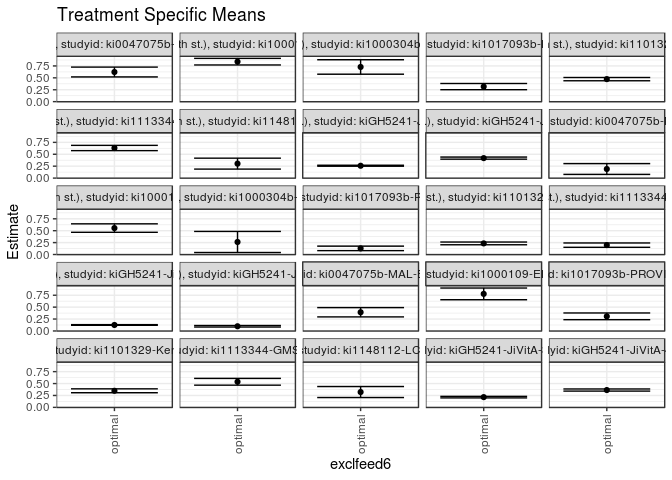

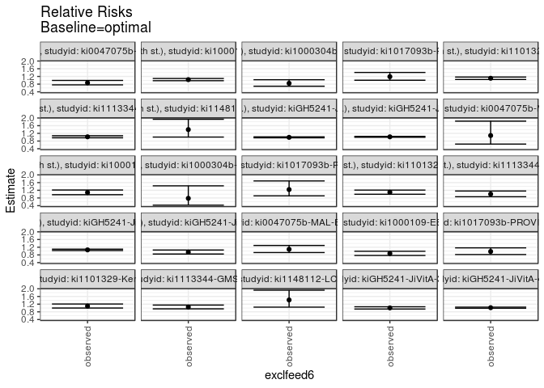

## Results Table

### Parameter: TSM

| agecat | studyid | country | intervention_level | baseline_level | estimate | ci_lower | ci_upper |
| --- | --- | --- | --- | --- | --- | --- | --- |
| 0-24 months (no birth st.) | ki0047075b-MAL-ED | BANGLADESH | optimal | NA | 0.6218844 | 0.5187767 | 0.7249921 |
| 0-24 months (no birth st.) | ki1000109-EE | PAKISTAN | optimal | NA | 0.8392443 | 0.7697933 | 0.9086953 |
| 0-24 months (no birth st.) | ki1000304b-SAS-CompFeed | INDIA | optimal | NA | 0.7282170 | 0.5763313 | 0.8801027 |
| 0-24 months (no birth st.) | ki1017093b-PROVIDE | BANGLADESH | optimal | NA | 0.3162593 | 0.2512093 | 0.3813094 |
| 0-24 months (no birth st.) | ki1101329-Keneba | GAMBIA | optimal | NA | 0.4729106 | 0.4384026 | 0.5074187 |
| 0-24 months (no birth st.) | ki1113344-GMS-Nepal | NEPAL | optimal | NA | 0.6315309 | 0.5759285 | 0.6871333 |
| 0-24 months (no birth st.) | ki1148112-LCNI-5 | MALAWI | optimal | NA | 0.3029675 | 0.1881621 | 0.4177729 |
| 0-24 months (no birth st.) | kiGH5241-JiVitA-3 | BANGLADESH | optimal | NA | 0.2587812 | 0.2485638 | 0.2689986 |
| 0-24 months (no birth st.) | kiGH5241-JiVitA-4 | BANGLADESH | optimal | NA | 0.4191190 | 0.3969021 | 0.4413360 |
| 0-6 months (no birth st.) | ki0047075b-MAL-ED | BANGLADESH | optimal | NA | 0.1905480 | 0.0772059 | 0.3038901 |
| 0-6 months (no birth st.) | ki1000109-EE | PAKISTAN | optimal | NA | 0.5551329 | 0.4662073 | 0.6440586 |
| 0-6 months (no birth st.) | ki1000304b-SAS-CompFeed | INDIA | optimal | NA | 0.2630258 | 0.0415842 | 0.4844674 |
| 0-6 months (no birth st.) | ki1017093b-PROVIDE | BANGLADESH | optimal | NA | 0.1285964 | 0.0811053 | 0.1760876 |
| 0-6 months (no birth st.) | ki1101329-Keneba | GAMBIA | optimal | NA | 0.2334195 | 0.2044359 | 0.2624032 |
| 0-6 months (no birth st.) | ki1113344-GMS-Nepal | NEPAL | optimal | NA | 0.1971028 | 0.1519348 | 0.2422708 |
| 0-6 months (no birth st.) | kiGH5241-JiVitA-3 | BANGLADESH | optimal | NA | 0.1254580 | 0.1184725 | 0.1324434 |
| 0-6 months (no birth st.) | kiGH5241-JiVitA-4 | BANGLADESH | optimal | NA | 0.0984400 | 0.0821505 | 0.1147295 |
| 6-24 months | ki0047075b-MAL-ED | BANGLADESH | optimal | NA | 0.3924646 | 0.2948586 | 0.4900705 |
| 6-24 months | ki1000109-EE | PAKISTAN | optimal | NA | 0.7781711 | 0.6553245 | 0.9010178 |
| 6-24 months | ki1017093b-PROVIDE | BANGLADESH | optimal | NA | 0.3068110 | 0.2359576 | 0.3776644 |
| 6-24 months | ki1101329-Keneba | GAMBIA | optimal | NA | 0.3484187 | 0.3075039 | 0.3893336 |
| 6-24 months | ki1113344-GMS-Nepal | NEPAL | optimal | NA | 0.5376200 | 0.4667907 | 0.6084493 |
| 6-24 months | ki1148112-LCNI-5 | MALAWI | optimal | NA | 0.3220383 | 0.2066550 | 0.4374217 |
| 6-24 months | kiGH5241-JiVitA-3 | BANGLADESH | optimal | NA | 0.2152208 | 0.1988233 | 0.2316183 |
| 6-24 months | kiGH5241-JiVitA-4 | BANGLADESH | optimal | NA | 0.3638780 | 0.3416792 | 0.3860767 |

### Parameter: E(Y)

| agecat | studyid | country | intervention_level | baseline_level | estimate | ci_lower | ci_upper |
| --- | --- | --- | --- | --- | --- | --- | --- |
| 0-24 months (no birth st.) | ki0047075b-MAL-ED | BANGLADESH | observed | NA | 0.5404040 | 0.4708115 | 0.6099965 |
| 0-24 months (no birth st.) | ki1000109-EE | PAKISTAN | observed | NA | 0.8674699 | 0.8252704 | 0.9096693 |
| 0-24 months (no birth st.) | ki1000304b-SAS-CompFeed | INDIA | observed | NA | 0.6134969 | 0.5286303 | 0.6983635 |
| 0-24 months (no birth st.) | ki1017093b-PROVIDE | BANGLADESH | observed | NA | 0.3753943 | 0.3376725 | 0.4131162 |
| 0-24 months (no birth st.) | ki1101329-Keneba | GAMBIA | observed | NA | 0.5219970 | 0.5002246 | 0.5437695 |
| 0-24 months (no birth st.) | ki1113344-GMS-Nepal | NEPAL | observed | NA | 0.6447106 | 0.6027601 | 0.6866610 |
| 0-24 months (no birth st.) | ki1148112-LCNI-5 | MALAWI | observed | NA | 0.4228571 | 0.3494545 | 0.4962598 |
| 0-24 months (no birth st.) | kiGH5241-JiVitA-3 | BANGLADESH | observed | NA | 0.2568529 | 0.2489241 | 0.2647817 |
| 0-24 months (no birth st.) | kiGH5241-JiVitA-4 | BANGLADESH | observed | NA | 0.4273377 | 0.4072583 | 0.4474171 |
| 0-6 months (no birth st.) | ki0047075b-MAL-ED | BANGLADESH | observed | NA | 0.2070707 | 0.1504870 | 0.2636544 |
| 0-6 months (no birth st.) | ki1000109-EE | PAKISTAN | observed | NA | 0.6024096 | 0.5415000 | 0.6633193 |
| 0-6 months (no birth st.) | ki1000304b-SAS-CompFeed | INDIA | observed | NA | 0.2055215 | 0.1385538 | 0.2724891 |
| 0-6 months (no birth st.) | ki1017093b-PROVIDE | BANGLADESH | observed | NA | 0.1593060 | 0.1307970 | 0.1878149 |
| 0-6 months (no birth st.) | ki1101329-Keneba | GAMBIA | observed | NA | 0.2560554 | 0.2370317 | 0.2750791 |
| 0-6 months (no birth st.) | ki1113344-GMS-Nepal | NEPAL | observed | NA | 0.1976048 | 0.1627023 | 0.2325072 |
| 0-6 months (no birth st.) | kiGH5241-JiVitA-3 | BANGLADESH | observed | NA | 0.1331973 | 0.1275046 | 0.1388899 |
| 0-6 months (no birth st.) | kiGH5241-JiVitA-4 | BANGLADESH | observed | NA | 0.0929124 | 0.0809295 | 0.1048954 |
| 6-24 months | ki0047075b-MAL-ED | BANGLADESH | observed | NA | 0.4285714 | 0.3501572 | 0.5069857 |
| 6-24 months | ki1000109-EE | PAKISTAN | observed | NA | 0.6804124 | 0.5871313 | 0.7736934 |
| 6-24 months | ki1017093b-PROVIDE | BANGLADESH | observed | NA | 0.2997812 | 0.2577294 | 0.3418330 |
| 6-24 months | ki1101329-Keneba | GAMBIA | observed | NA | 0.3823738 | 0.3569722 | 0.4077755 |
| 6-24 months | ki1113344-GMS-Nepal | NEPAL | observed | NA | 0.5642317 | 0.5153938 | 0.6130696 |
| 6-24 months | ki1148112-LCNI-5 | MALAWI | observed | NA | 0.4567901 | 0.3798457 | 0.5337346 |
| 6-24 months | kiGH5241-JiVitA-3 | BANGLADESH | observed | NA | 0.2160008 | 0.2065441 | 0.2254575 |
| 6-24 months | kiGH5241-JiVitA-4 | BANGLADESH | observed | NA | 0.3699441 | 0.3495174 | 0.3903708 |

### Parameter: RR

| agecat | studyid | country | intervention_level | baseline_level | estimate | ci_lower | ci_upper |
| --- | --- | --- | --- | --- | --- | --- | --- |
| 0-24 months (no birth st.) | ki0047075b-MAL-ED | BANGLADESH | observed | optimal | 0.8689783 | 0.7616574 | 0.9914212 |
| 0-24 months (no birth st.) | ki1000109-EE | PAKISTAN | observed | optimal | 1.0336321 | 0.9777800 | 1.0926745 |
| 0-24 months (no birth st.) | ki1000304b-SAS-CompFeed | INDIA | observed | optimal | 0.8424645 | 0.6901254 | 1.0284310 |
| 0-24 months (no birth st.) | ki1017093b-PROVIDE | BANGLADESH | observed | optimal | 1.1869827 | 1.0017244 | 1.4065024 |
| 0-24 months (no birth st.) | ki1101329-Keneba | GAMBIA | observed | optimal | 1.1037964 | 1.0428866 | 1.1682636 |
| 0-24 months (no birth st.) | ki1113344-GMS-Nepal | NEPAL | observed | optimal | 1.0208694 | 0.9690831 | 1.0754232 |
| 0-24 months (no birth st.) | ki1148112-LCNI-5 | MALAWI | observed | optimal | 1.3957179 | 1.0076527 | 1.9332341 |
| 0-24 months (no birth st.) | kiGH5241-JiVitA-3 | BANGLADESH | observed | optimal | 0.9925485 | 0.9689692 | 1.0167017 |
| 0-24 months (no birth st.) | kiGH5241-JiVitA-4 | BANGLADESH | observed | optimal | 1.0196094 | 0.9967944 | 1.0429466 |
| 0-6 months (no birth st.) | ki0047075b-MAL-ED | BANGLADESH | observed | optimal | 1.0867116 | 0.6435027 | 1.8351781 |
| 0-6 months (no birth st.) | ki1000109-EE | PAKISTAN | observed | optimal | 1.0851629 | 0.9700324 | 1.2139578 |
| 0-6 months (no birth st.) | ki1000304b-SAS-CompFeed | INDIA | observed | optimal | 0.7813737 | 0.4262552 | 1.4323461 |
| 0-6 months (no birth st.) | ki1017093b-PROVIDE | BANGLADESH | observed | optimal | 1.2388056 | 0.9103766 | 1.6857194 |
| 0-6 months (no birth st.) | ki1101329-Keneba | GAMBIA | observed | optimal | 1.0969749 | 0.9945539 | 1.2099433 |
| 0-6 months (no birth st.) | ki1113344-GMS-Nepal | NEPAL | observed | optimal | 1.0025466 | 0.8651115 | 1.1618153 |
| 0-6 months (no birth st.) | kiGH5241-JiVitA-3 | BANGLADESH | observed | optimal | 1.0616883 | 1.0262832 | 1.0983148 |
| 0-6 months (no birth st.) | kiGH5241-JiVitA-4 | BANGLADESH | observed | optimal | 0.9438482 | 0.8454164 | 1.0537405 |
| 6-24 months | ki0047075b-MAL-ED | BANGLADESH | observed | optimal | 1.0920003 | 0.9232610 | 1.2915793 |
| 6-24 months | ki1000109-EE | PAKISTAN | observed | optimal | 0.8743737 | 0.7722340 | 0.9900230 |
| 6-24 months | ki1017093b-PROVIDE | BANGLADESH | observed | optimal | 0.9770875 | 0.8185132 | 1.1663831 |
| 6-24 months | ki1101329-Keneba | GAMBIA | observed | optimal | 1.0974549 | 0.9985891 | 1.2061089 |
| 6-24 months | ki1113344-GMS-Nepal | NEPAL | observed | optimal | 1.0494992 | 0.9559058 | 1.1522563 |
| 6-24 months | ki1148112-LCNI-5 | MALAWI | observed | optimal | 1.4184340 | 1.0453621 | 1.9246488 |
| 6-24 months | kiGH5241-JiVitA-3 | BANGLADESH | observed | optimal | 1.0036241 | 0.9461746 | 1.0645618 |
| 6-24 months | kiGH5241-JiVitA-4 | BANGLADESH | observed | optimal | 1.0166708 | 0.9889433 | 1.0451757 |

### Parameter: PAR

| agecat | studyid | country | intervention_level | baseline_level | estimate | ci_lower | ci_upper |
| --- | --- | --- | --- | --- | --- | --- | --- |
| 0-24 months (no birth st.) | ki0047075b-MAL-ED | BANGLADESH | optimal | NA | -0.0814803 | -0.1621185 | -0.0008422 |
| 0-24 months (no birth st.) | ki1000109-EE | PAKISTAN | optimal | NA | 0.0282256 | -0.0180584 | 0.0745095 |
| 0-24 months (no birth st.) | ki1000304b-SAS-CompFeed | INDIA | optimal | NA | -0.1147200 | -0.2563572 | 0.0269171 |
| 0-24 months (no birth st.) | ki1017093b-PROVIDE | BANGLADESH | optimal | NA | 0.0591350 | 0.0057350 | 0.1125350 |
| 0-24 months (no birth st.) | ki1101329-Keneba | GAMBIA | optimal | NA | 0.0490864 | 0.0223215 | 0.0758513 |
| 0-24 months (no birth st.) | ki1113344-GMS-Nepal | NEPAL | optimal | NA | 0.0131797 | -0.0196064 | 0.0459658 |
| 0-24 months (no birth st.) | ki1148112-LCNI-5 | MALAWI | optimal | NA | 0.1198897 | 0.0203445 | 0.2194348 |
| 0-24 months (no birth st.) | kiGH5241-JiVitA-3 | BANGLADESH | optimal | NA | -0.0019283 | -0.0081516 | 0.0042950 |
| 0-24 months (no birth st.) | kiGH5241-JiVitA-4 | BANGLADESH | optimal | NA | 0.0082187 | -0.0012577 | 0.0176950 |
| 0-6 months (no birth st.) | ki0047075b-MAL-ED | BANGLADESH | optimal | NA | 0.0165227 | -0.0833515 | 0.1163969 |
| 0-6 months (no birth st.) | ki1000109-EE | PAKISTAN | optimal | NA | 0.0472767 | -0.0145644 | 0.1091179 |
| 0-6 months (no birth st.) | ki1000304b-SAS-CompFeed | INDIA | optimal | NA | -0.0575044 | -0.2287314 | 0.1137227 |
| 0-6 months (no birth st.) | ki1017093b-PROVIDE | BANGLADESH | optimal | NA | 0.0307096 | -0.0088131 | 0.0702322 |
| 0-6 months (no birth st.) | ki1101329-Keneba | GAMBIA | optimal | NA | 0.0226358 | -0.0002715 | 0.0455432 |
| 0-6 months (no birth st.) | ki1113344-GMS-Nepal | NEPAL | optimal | NA | 0.0005020 | -0.0285598 | 0.0295637 |
| 0-6 months (no birth st.) | kiGH5241-JiVitA-3 | BANGLADESH | optimal | NA | 0.0077393 | 0.0034854 | 0.0119932 |
| 0-6 months (no birth st.) | kiGH5241-JiVitA-4 | BANGLADESH | optimal | NA | -0.0055276 | -0.0163582 | 0.0053030 |
| 6-24 months | ki0047075b-MAL-ED | BANGLADESH | optimal | NA | 0.0361069 | -0.0300791 | 0.1022929 |
| 6-24 months | ki1000109-EE | PAKISTAN | optimal | NA | -0.0977588 | -0.1916517 | -0.0038658 |
| 6-24 months | ki1017093b-PROVIDE | BANGLADESH | optimal | NA | -0.0070298 | -0.0614164 | 0.0473568 |
| 6-24 months | ki1101329-Keneba | GAMBIA | optimal | NA | 0.0339551 | 0.0010686 | 0.0668417 |
| 6-24 months | ki1113344-GMS-Nepal | NEPAL | optimal | NA | 0.0266117 | -0.0234971 | 0.0767206 |
| 6-24 months | ki1148112-LCNI-5 | MALAWI | optimal | NA | 0.1347518 | 0.0353678 | 0.2341358 |
| 6-24 months | kiGH5241-JiVitA-3 | BANGLADESH | optimal | NA | 0.0007800 | -0.0119037 | 0.0134636 |
| 6-24 months | kiGH5241-JiVitA-4 | BANGLADESH | optimal | NA | 0.0060661 | -0.0040113 | 0.0161436 |

### Parameter: PAF

| agecat | studyid | country | intervention_level | baseline_level | estimate | ci_lower | ci_upper |
| --- | --- | --- | --- | --- | --- | --- | --- |
| 0-24 months (no birth st.) | ki0047075b-MAL-ED | BANGLADESH | optimal | NA | -0.1507767 | -0.3129263 | -0.0086530 |
| 0-24 months (no birth st.) | ki1000109-EE | PAKISTAN | optimal | NA | 0.0325378 | -0.0227249 | 0.0848144 |
| 0-24 months (no birth st.) | ki1000304b-SAS-CompFeed | INDIA | optimal | NA | -0.1869937 | -0.4490119 | 0.0276450 |
| 0-24 months (no birth st.) | ki1017093b-PROVIDE | BANGLADESH | optimal | NA | 0.1575277 | 0.0017215 | 0.2890165 |
| 0-24 months (no birth st.) | ki1101329-Keneba | GAMBIA | optimal | NA | 0.0940358 | 0.0411230 | 0.1440288 |
| 0-24 months (no birth st.) | ki1113344-GMS-Nepal | NEPAL | optimal | NA | 0.0204428 | -0.0319033 | 0.0701335 |
| 0-24 months (no birth st.) | ki1148112-LCNI-5 | MALAWI | optimal | NA | 0.2835228 | 0.0075945 | 0.4827321 |
| 0-24 months (no birth st.) | kiGH5241-JiVitA-3 | BANGLADESH | optimal | NA | -0.0075074 | -0.0320246 | 0.0164273 |
| 0-24 months (no birth st.) | kiGH5241-JiVitA-4 | BANGLADESH | optimal | NA | 0.0192322 | -0.0032159 | 0.0411781 |
| 0-6 months (no birth st.) | ki0047075b-MAL-ED | BANGLADESH | optimal | NA | 0.0797926 | -0.5539950 | 0.4550938 |
| 0-6 months (no birth st.) | ki1000109-EE | PAKISTAN | optimal | NA | 0.0784794 | -0.0308934 | 0.1762482 |
| 0-6 months (no birth st.) | ki1000304b-SAS-CompFeed | INDIA | optimal | NA | -0.2797973 | -1.3460126 | 0.3018447 |
| 0-6 months (no birth st.) | ki1017093b-PROVIDE | BANGLADESH | optimal | NA | 0.1927709 | -0.0984466 | 0.4067815 |
| 0-6 months (no birth st.) | ki1101329-Keneba | GAMBIA | optimal | NA | 0.0884021 | -0.0054759 | 0.1735150 |
| 0-6 months (no birth st.) | ki1113344-GMS-Nepal | NEPAL | optimal | NA | 0.0025402 | -0.1559204 | 0.1392780 |
| 0-6 months (no birth st.) | kiGH5241-JiVitA-3 | BANGLADESH | optimal | NA | 0.0581040 | 0.0256101 | 0.0895142 |
| 0-6 months (no birth st.) | kiGH5241-JiVitA-4 | BANGLADESH | optimal | NA | -0.0594924 | -0.1828491 | 0.0509997 |
| 6-24 months | ki0047075b-MAL-ED | BANGLADESH | optimal | NA | 0.0842494 | -0.0831173 | 0.2257541 |
| 6-24 months | ki1000109-EE | PAKISTAN | optimal | NA | -0.1436757 | -0.2949443 | -0.0100776 |
| 6-24 months | ki1017093b-PROVIDE | BANGLADESH | optimal | NA | -0.0234498 | -0.2217274 | 0.1426487 |
| 6-24 months | ki1101329-Keneba | GAMBIA | optimal | NA | 0.0888008 | -0.0014129 | 0.1708875 |
| 6-24 months | ki1113344-GMS-Nepal | NEPAL | optimal | NA | 0.0471645 | -0.0461282 | 0.1321375 |
| 6-24 months | ki1148112-LCNI-5 | MALAWI | optimal | NA | 0.2949971 | 0.0433937 | 0.4804247 |
| 6-24 months | kiGH5241-JiVitA-3 | BANGLADESH | optimal | NA | 0.0036110 | -0.0568873 | 0.0606463 |
| 6-24 months | kiGH5241-JiVitA-4 | BANGLADESH | optimal | NA | 0.0163974 | -0.0111804 | 0.0432231 |